# Deliverable Part 2

My second source is a website of crime statistics that compares LA crimes to the California and National averages.It has 7 different variables for types of crimes and each crime has 4 sections to put the number to scale.

# SYNOPSIS

## In my LA_crime table I will use the variables

Continuous  
***  
Reported (The amount of crime instances reported in one year)

Categorical  
*** Crime_type (Type of crime committed)

## In my Comparison table I will use the variables

Continuous  
***  
CA_Annual (The annual average of a crime in California per 100k instances)  
National_Annual (The Annual average of a crime internationally per 100k instances)

Categorical  
***  
Crime_type (The type of crime committed)

# Data Initialization

Here is where I load in my libraries and data, I’m using a website so I have to web scrape the data.

```r
#install.packages("tidyverse")
library("ggplot2")
library("tidyverse")
library("readr")
library("dplyr")
library("tidyr")
library("rvest")
library("caret")
library("knitr")
library("plyr")
#This is where I pull my first deliverable as my source
purl("Part1.Rmd", output = "part1.r")
```

```
## [1] "Part1.R"
```

```r
source("part1.r")
```

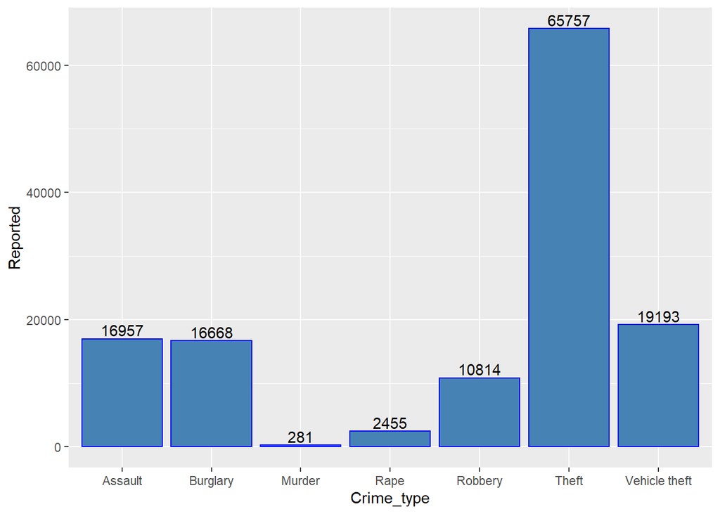

```r
my_url<-"https://www.areavibes.com/los+angeles-ca/crime/"
crime_html<-read_html(my_url)
#Statistics<- crime_html %>% html_nodes("tr:not(.header) > td:nth-child(1)") %>% html_text

Crime_type<- crime_html %>%
            html_nodes("table.is-city tr:not(.header):not(.summary) > td:nth-child(1)") %>%
  html_text()

Reported<- crime_html %>%
            html_nodes("table.is-city tr:not(.header):not(.summary) > td:nth-child(2)") %>%
  html_text()
Reported<-as.numeric(gsub(",","",Reported,fixed=TRUE))

LA_Annual<-crime_html %>%
            html_nodes("table.is-city tr:not(.header):not(.summary) > td:nth-child(4)") %>%
  html_text()
LA_Annual<-as.numeric(gsub(",","",LA_Annual,fixed=TRUE))

CA_Annual<-crime_html %>%
            html_nodes("table.is-city tr:not(.header):not(.summary) > td:nth-child(5)") %>%
  html_text()
CA_Annual<-as.numeric(gsub(",","",CA_Annual,fixed=TRUE))

National_Annual<- crime_html %>%
            html_nodes("table.is-city tr:not(.header):not(.summary) > td:nth-child(6)") %>%
  html_text()
National_Annual<-as.numeric(gsub(",","",National_Annual,fixed=TRUE))


LA_Crime<-tibble(Crime_type = Crime_type, Reported = Reported)

Comparison<-tibble(Crime_type = Crime_type, LA_Annual = LA_Annual, CA_Annual = CA_Annual, National_Annual = National_Annual)

Comparison<-gather(Comparison, "Locale", "Count",2:4)

ggplot(data = LA_Crime, aes(x = Crime_type, y = Reported)) + geom_bar(colour = "blue", stat = "identity",fill = "steelblue")+geom_text(aes(label=Reported), position=position_dodge(width=0.9), vjust=-0.25)
```

## In this next chunk of code I will compare LA’s annual crime (per 100k citizens) to the rest of California, and the rest of America.

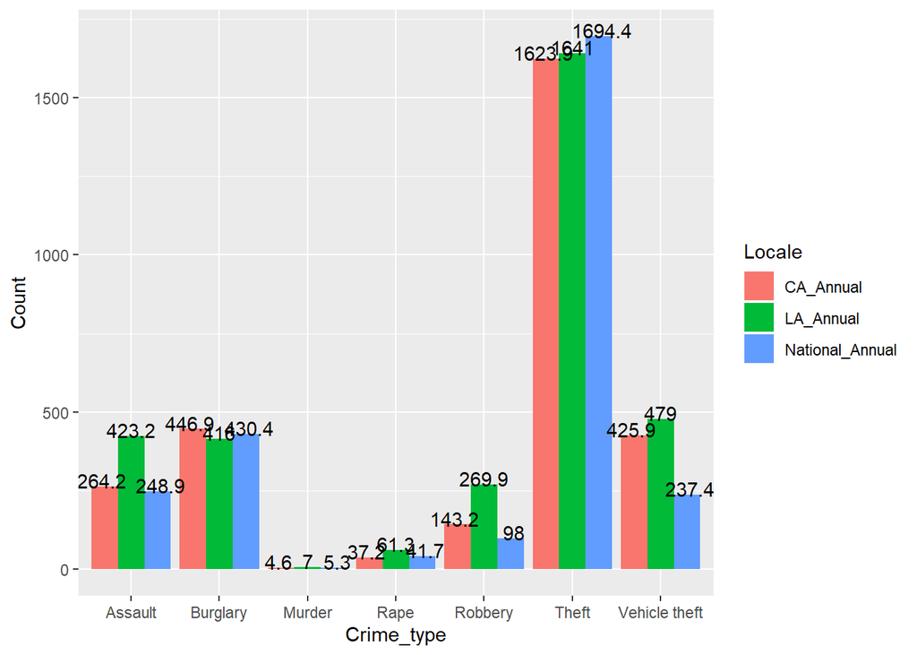

```r
ggplot(data = Comparison, aes(fill = Locale, x = Crime_type, y = Count)) + geom_bar(position = "dodge",stat = "identity") + geom_text(aes(label=Count), position=position_dodge(width=1.0), vjust=.1)
```

```r
countOfStolenVehicle
```

```
##                  x   freq
## 1 VEHICLE - STOLEN 151622
```

```r
countOfBattery
```

```
##                          x   freq
## 1 BATTERY - SIMPLE ASSAULT 180434
```

```r
countOfBurglary
```

```
##                       x   freq
## 1 BURGLARY FROM VEHICLE 153451
```

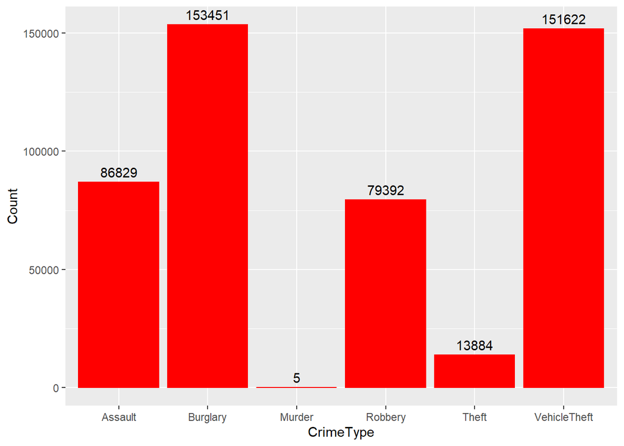

```r
countOfAssault<-count(CrimeDetails$Crime_Description[CrimeDetails$Crime_Description == "ASSAULT WITH DEADLY WEAPON, AGGRAVATED ASSAULT"])
countOfMurder<-count(CrimeDetails$Crime_Description[CrimeDetails$Crime_Description == "MANSLAUGHTER, NEGLIGENT"])
countOfRobbery<-count(CrimeDetails$Crime_Description[CrimeDetails$Crime_Description == "ROBBERY"])
countOfTheft<-count(CrimeDetails$Crime_Description[CrimeDetails$Crime_Description == "THEFT, PERSON"])

crimeCount<-c(countOfAssault$freq, countOfBurglary$freq, countOfMurder$freq, countOfRobbery$freq, countOfTheft$freq,countOfStolenVehicle$freq)
crimesToCheck<-c("Assault", "Burglary", "Murder", "Robbery", "Theft", "VehicleTheft")
actualReported<-tibble(CrimeType = crimesToCheck, Count = crimeCount)


ggplot(data = actualReported, aes(x = CrimeType, y = Count)) + geom_bar(stat = "identity", colour = "red", fill = "red") + geom_text(aes(label=Count), position=position_dodge(width=1.0), vjust=-.5)
```

## Data Translation

As you can see from my graph, LA dominates the other 2 annual reportings when it comes to crime. Theft in LA per 100k people is almost as high as the national average for theft per 100k reported crimes. The only other category where LA wasn’t leading was Burglary.

# Modeling My Data

Here I will run code to make a linear regression and see the correlation between the Count of crimes in a year, Locale, or Crime_type. If we get a low p-value that is below 0.05 then they have a good correlation.

```r
##Here I make a simple model showing to see if the variables have correlation with Count
simple_model<-lm(Comparison, formula = Count ~ Locale + Crime_type)
summary(simple_model)
```

```
##
## Call:
## lm(formula = Count ~ Locale + Crime_type, data = Comparison)
##
## Residuals:
##      Min       1Q   Median       3Q      Max
## -108.552  -37.552   -1.833   34.481   76.114
##
## Coefficients:
##                         Estimate Std. Error t value Pr(>|t|)
## (Intercept)               304.40      41.71   7.298 9.51e-06 ***
## LocaleLA_Annual            50.21      34.06   1.474 0.166124
## LocaleNational_Annual     -27.11      34.06  -0.796 0.441425
## Crime_typeBurglary        119.00      52.02   2.287 0.041125 *
## Crime_typeMurder         -306.47      52.02  -5.891 7.36e-05 ***
## Crime_typeRape           -265.37      52.02  -5.101 0.000261 ***
## Crime_typeRobbery        -141.73      52.02  -2.724 0.018458 *
## Crime_typeTheft          1341.00      52.02  25.776 7.09e-12 ***
## Crime_typeVehicle theft    68.67      52.02   1.320 0.211494
## ---
## Signif. codes:  0 '***' 0.001 '**' 0.01 '*' 0.05 '.' 0.1 ' ' 1
##
## Residual standard error: 63.72 on 12 degrees of freedom
## Multiple R-squared:  0.9916, Adjusted R-squared:  0.986
## F-statistic: 176.8 on 8 and 12 DF,  p-value: 2.916e-11
```

```r
##Here I create a training sample and a testing sample, with these we can make predictions on crime Count. Since locale wasn't a good indicator we can omit it.
set.seed(385)
sample<-createDataPartition(Comparison$Count,p = 0.75, list = FALSE)
train<-Comparison[sample, ]
test<-Comparison[-sample, ]

trainmodel<-lm(formula = Count ~  Crime_type, data = Comparison)
summary(trainmodel)
```

```
##
## Call:
## lm(formula = Count ~ Crime_type, data = Comparison)
##
## Residuals:
##      Min       1Q   Median       3Q      Max
## -143.367  -27.167   -1.033   15.800  111.100
##
## Coefficients:
##                         Estimate Std. Error t value Pr(>|t|)
## (Intercept)               312.10      40.90   7.630 2.37e-06 ***
## Crime_typeBurglary        119.00      57.85   2.057 0.058797 .
## Crime_typeMurder         -306.47      57.85  -5.298 0.000113 ***
## Crime_typeRape           -265.37      57.85  -4.587 0.000422 ***
## Crime_typeRobbery        -141.73      57.85  -2.450 0.028033 *
## Crime_typeTheft          1341.00      57.85  23.182 1.44e-12 ***
## Crime_typeVehicle theft    68.67      57.85   1.187 0.254955
## ---
## Signif. codes:  0 '***' 0.001 '**' 0.01 '*' 0.05 '.' 0.1 ' ' 1
##
## Residual standard error: 70.85 on 14 degrees of freedom
## Multiple R-squared:  0.9879, Adjusted R-squared:  0.9827
## F-statistic: 189.9 on 6 and 14 DF,  p-value: 1.366e-12
```

```r
testmodel<-lm(formula = Count ~ Crime_type, data = Comparison)
summary(testmodel)
```

```
##
## Call:
## lm(formula = Count ~ Crime_type, data = Comparison)
##
## Residuals:
##      Min       1Q   Median       3Q      Max
## -143.367  -27.167   -1.033   15.800  111.100
##
## Coefficients:
##                         Estimate Std. Error t value Pr(>|t|)
## (Intercept)               312.10      40.90   7.630 2.37e-06 ***
## Crime_typeBurglary        119.00      57.85   2.057 0.058797 .
## Crime_typeMurder         -306.47      57.85  -5.298 0.000113 ***
## Crime_typeRape           -265.37      57.85  -4.587 0.000422 ***
## Crime_typeRobbery        -141.73      57.85  -2.450 0.028033 *
## Crime_typeTheft          1341.00      57.85  23.182 1.44e-12 ***
## Crime_typeVehicle theft    68.67      57.85   1.187 0.254955
## ---
## Signif. codes:  0 '***' 0.001 '**' 0.01 '*' 0.05 '.' 0.1 ' ' 1
##
## Residual standard error: 70.85 on 14 degrees of freedom
## Multiple R-squared:  0.9879, Adjusted R-squared:  0.9827
## F-statistic: 189.9 on 6 and 14 DF,  p-value: 1.366e-12
```

```r
prediction<-trainmodel %>% predict(test)

results <- data.frame( R2 = R2(prediction, test$Count),
            RMSE = RMSE(prediction, test$Count),
            MAE = MAE(prediction, test$Count))
results
```

```
##          R2     RMSE      MAE
## 1 0.9897837 65.55905 51.21667
```

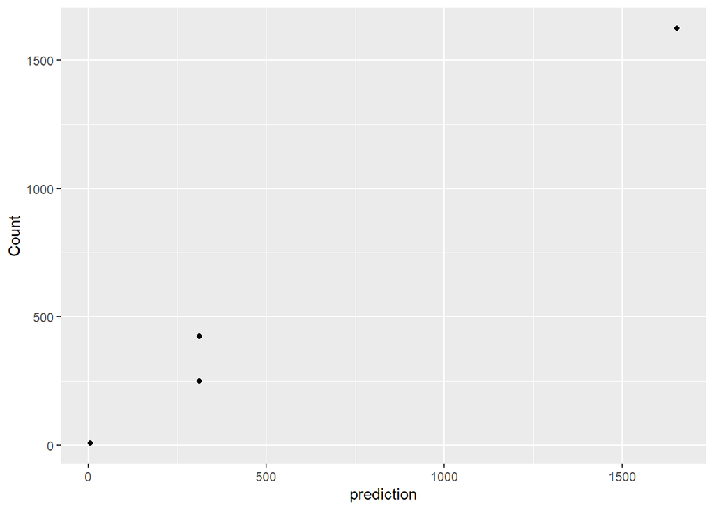

```r
ggplot(data = test, aes(x = prediction, y = Count), ) + geom_point()
```

Although locale doesn’t effect Count too much we can see that the crime type is a strong correlation.